# Compare controls

# Investigate the impact of read cutoff

The plot below indicates that there are a high number of OTUs with low support. A cutoff of 15 reads appears to be suitable, with the number of OTUs remaining fairly stable for higher cutoffs.

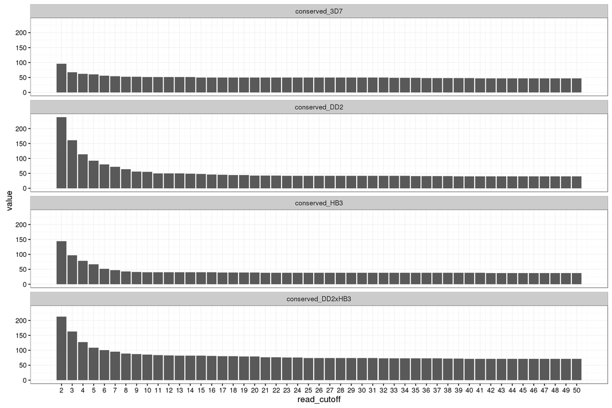

```r
read_cutoff_df <- data.frame()
for (min_reads in seq(2, 50, by = 1)) {
    conserved_3D7 <- length(getConservedTypes(otus_3D7, min_reads))
    conserved_DD2 <- length(getConservedTypes(otus_DD2, min_reads))
    conserved_HB3 <- length(getConservedTypes(otus_HB3, min_reads))
    conserved_DD2xHB3 <- length(getConservedTypes(otus_DD2xHB3, min_reads))
    temp_df <- data.frame(read_cutoff = min_reads, conserved_3D7 = conserved_3D7,
        conserved_DD2 = conserved_DD2, conserved_HB3 = conserved_HB3, conserved_DD2xHB3 = conserved_DD2xHB3)
    read_cutoff_df <- rbind(read_cutoff_df, temp_df)
}

read_cutoff_melt_df <- melt(read_cutoff_df, id.vars = "read_cutoff", variable.name = "Isolate")
gg <- ggplot(read_cutoff_melt_df, aes(x = read_cutoff, y = value)) + geom_bar(stat = "identity")
gg <- gg + facet_wrap(~Isolate, ncol = 1)
gg <- gg + theme_bw() + scale_x_continuous(breaks = seq(2, 50, 1))  # + scale_y_sqrt()
gg
```

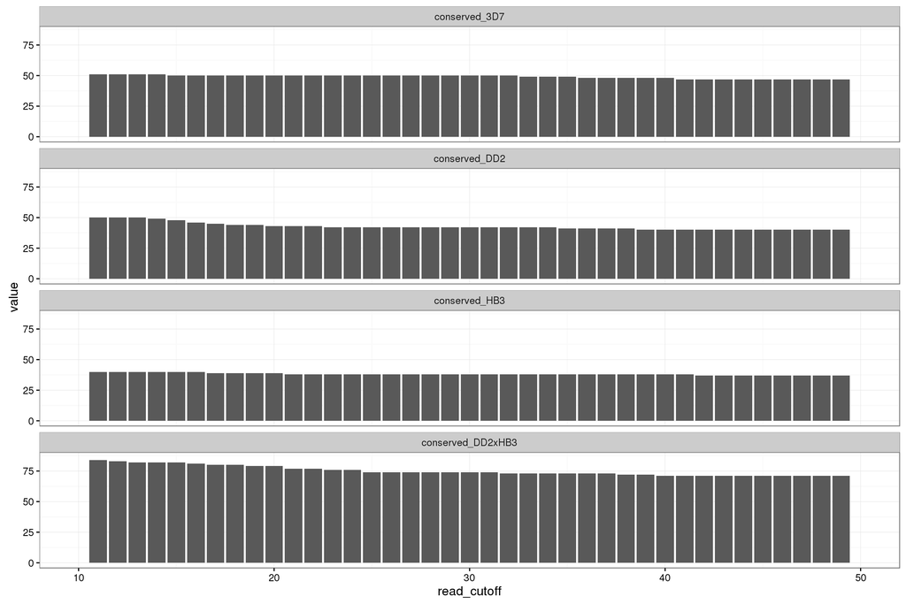

```r
gg + xlim(10, 50)
```

Another plot gives support to the 15 read cutoff. Here we show the number of OTUs for differing levels of support. Again the high number of OTUs with low support can be seen with a cutoff of 15 appearing appropriate. This plot also indicates that the remaining OTUs have a wide variety of read support.

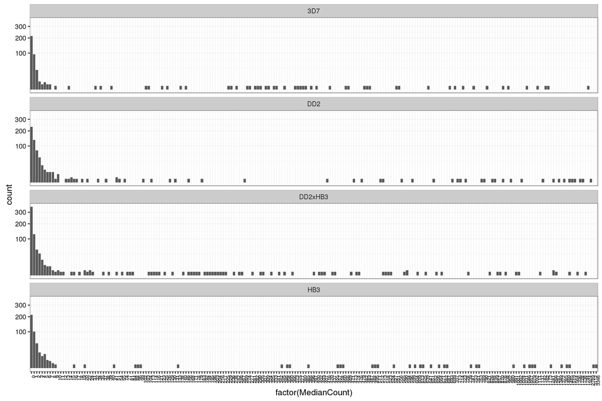

```r
setwd(wd)

getOtuReadCounts <- function(otu_df) {
    chimericCols <- grepl(".*ncdenovo.*", colnames(otu_df)) | grepl(".*ncref.*",
        colnames(otu_df)) | grepl(".*otuclust.*", colnames(otu_df))
    nofiltering_otus <- otu_df[, !chimericCols]
    nofiltering_otus <- data.matrix(nofiltering_otus[, 2:ncol(nofiltering_otus)])
    rownames(nofiltering_otus) <- otu_df$`#OTU ID`

    return(apply(nofiltering_otus, 1, median))
}

otus_3D7_noFilter <- getOtuReadCounts(otus_3D7)
otus_HB3_noFilter <- getOtuReadCounts(otus_HB3)
otus_DD2_noFilter <- getOtuReadCounts(otus_DD2)
otus_DD2xHB3_noFilter <- getOtuReadCounts(otus_DD2xHB3)


combinedMedianCounts <- data.frame(Otus = c(names(otus_3D7_noFilter), names(otus_HB3_noFilter),
    names(otus_DD2_noFilter), names(otus_DD2xHB3_noFilter)), MedianCount = c(otus_3D7_noFilter,
    otus_HB3_noFilter, otus_DD2_noFilter, otus_DD2xHB3_noFilter), Isolate = c(rep("3D7",
    length(otus_3D7_noFilter)), rep("HB3", length(otus_HB3_noFilter)), rep("DD2",
    length(otus_DD2_noFilter)), rep("DD2xHB3", length(otus_DD2xHB3_noFilter))))

gg <- ggplot(combinedMedianCounts, aes(x = factor(MedianCount)))
gg <- gg + geom_bar()
gg <- gg + facet_wrap(~Isolate, ncol = 1)
gg <- gg + scale_y_sqrt()
gg <- gg + theme_bw() + theme(axis.text.x = element_text(size = 7, angle = 90,
    hjust = 1))
gg
```

The plot below indicates the number of conserved types found for each isolate with a read cutoff of 15, clustered at 96% identity.

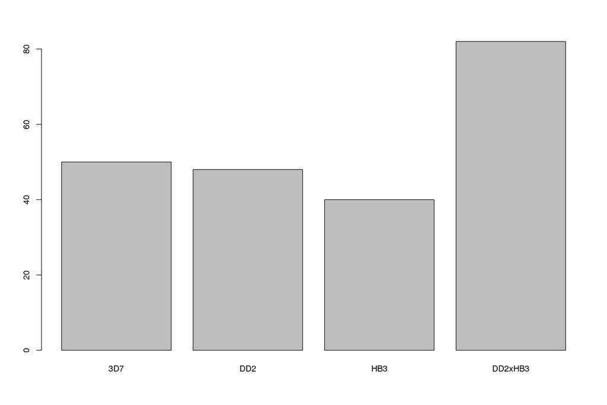

```r
MIN_READS = 15

conserved_3D7 <- getConservedTypes(otus_3D7, MIN_READS)
conserved_DD2 <- getConservedTypes(otus_DD2, MIN_READS)
conserved_HB3 <- getConservedTypes(otus_HB3, MIN_READS)
conserved_DD2xHB3 <- getConservedTypes(otus_DD2xHB3, MIN_READS)

barplot(unlist(lapply(list(conserved_3D7, conserved_DD2, conserved_HB3, conserved_DD2xHB3),
    length)), names.arg = c("3D7", "DD2", "HB3", "DD2xHB3"))
```

```r
unlist(lapply(list(conserved_3D7, conserved_DD2, conserved_HB3, conserved_DD2xHB3),
    length))
```

```
## [1] 50 48 40 82
```